# identifiability check part 3

$\nu_1 = 0.6 \theta_1 + 0.4 \theta_2$ $\nu_2 = 0.4 \theta_1 + 0.6 \theta_2$

We first take the admixture proportions.

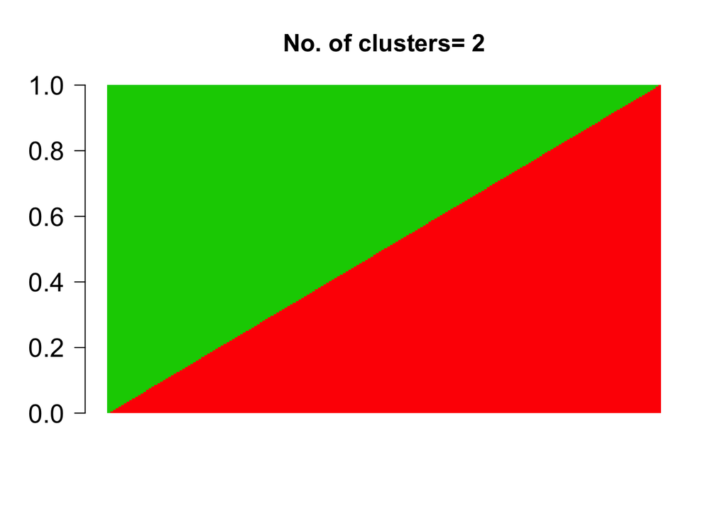

```r
library(maptpx)
n.out <- 200
omega_sim <- cbind(seq(0,1,length.out=n.out), 1- seq(0,1,length.out=n.out));
K <- dim(omega_sim)[2];
barplot(t(omega_sim),col=2:(K+1),axisnames=F,space=0,border=NA,main=paste("No. of clusters=",K),las=1,ylim=c(0,1),cex.axis=1.5,cex.main=1.4)
```

Next we define the relative gene expression.

```r
freq2 <- matrix(0,2,length(freq1[1,]))
freq2[1,] <- 0.6*freq1[1,]+0.4*freq1[2,];
freq2[2,] <- 0.6*freq1[2,]+0.4*freq1[1,];
```

Next we generate the counts data and apply the Admixture model and plot the Structure plot.

```r
counts <- t(do.call(cbind,lapply(1:dim(omega_sim)[1], function(x) rmultinom(1,1000,prob=omega_sim[x,]%*%freq2))));

Topic_clus <- topics(counts, K=2,tol=0.001);
```

```
##
## Estimating on a 200 document collection.
## Fitting the 2 topic model.
## log posterior increase: 16.607, 9.115, 0.781, 0.722, 0.673, 0.632, 0.597, 0.57, 0.549, 0.535, 0.529, 0.53, 0.54, 0.562, 0.597, 0.648, 0.722, 0.821, 0.952, 1.116, 1.311, 1.522, 1.725, 1.887, 1.983, 2.006, 1.966, 1.885, 1.778, 1.659, 1.532, 1.401, 1.268, 1.135, 1.006, 0.881, 0.763, 0.654, 0.553, 0.…
```

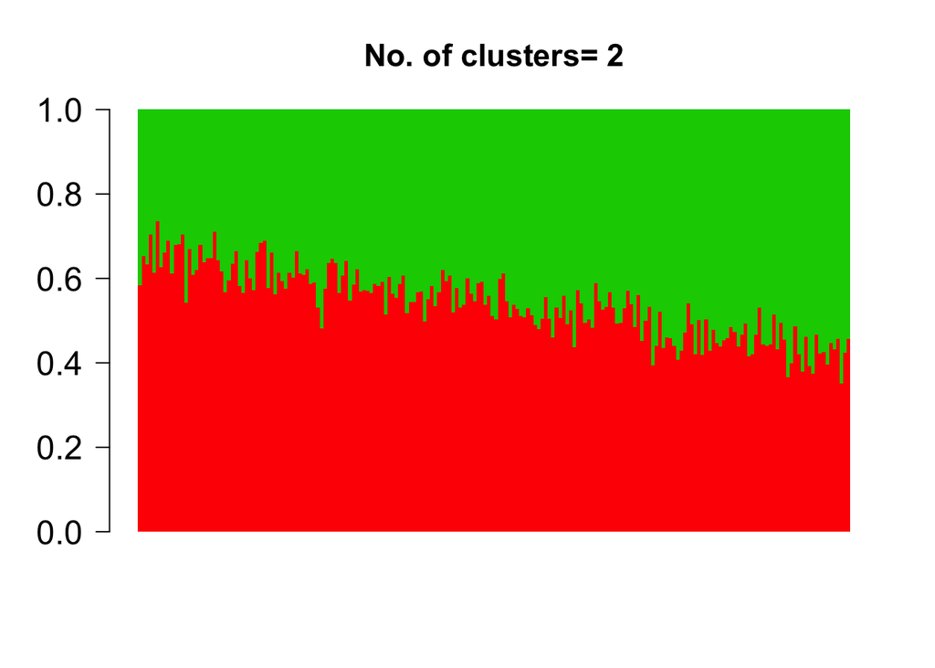

```r
K=2
barplot(t(Topic_clus$omega),col=2:(K+1),axisnames=F,space=0,border=NA,main=paste("No. of clusters=",K),las=1,ylim=c(0,1),cex.axis=1.5,cex.main=1.4)
```

The gene annotations reveal the top genes as

```
## [1]   2 100   1  99
```

## Second set up

In this set up, we keep the gene frequencies as before but we do not vary the admixture proportions continuously, rather we keep them fixed at a particular value.

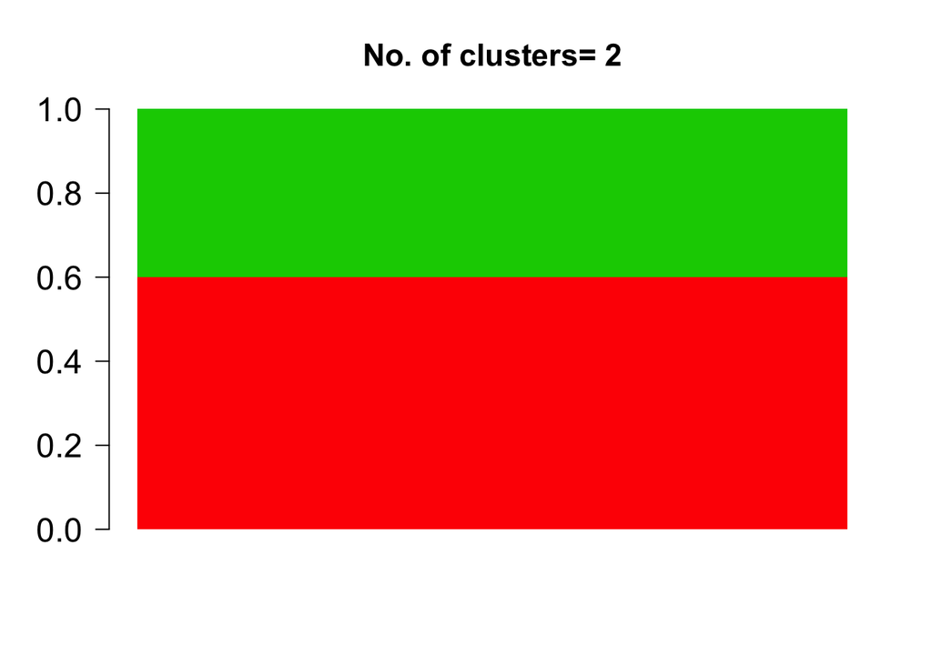

```r
library(maptpx)
n.out <- 200
omega_sim <- cbind(rep(0.6,n.out), 1- rep(0.6,n.out));
K <- dim(omega_sim)[2];
barplot(t(omega_sim),col=2:(K+1),axisnames=F,space=0,border=NA,main=paste("No. of clusters=",K),las=1,ylim=c(0,1),cex.axis=1.5,cex.main=1.4)
```

Next we read in the $\theta$ values we reported above

```r
freq1 <- rbind(c(0.1,0.2,rep(0.70/98,98)),c(rep(0.70/98,98), 0.1,0.2));
```

Next we generate the counts data and apply the Admixture model and plot the Structure plot.

```r
counts <- t(do.call(cbind,lapply(1:dim(omega_sim)[1], function(x) rmultinom(1,1000,prob=omega_sim[x,]%*%freq1))));

Topic_clus <- topics(counts, K=2,tol=0.001);
```

```
##
## Estimating on a 200 document collection.
## Fitting the 2 topic model.
## log posterior increase: 18.071, 10.326, 0.614, 0.544, 0.486, 0.438, 0.398, 0.364, 0.335, 0.31, 0.289, 0.27, 0.254, 0.24, 0.227, 0.216, 0.206, 0.197, 0.189, 0.181, 0.175, 0.168, 0.163, 0.157, 0.152, 0.147, 0.143, 0.138, 0.134, 0.13, 0.125, 0.121, 0.117, 0.113, 0.109, 0.104, 0.1, 0.096, 0.092, 0.08…
```

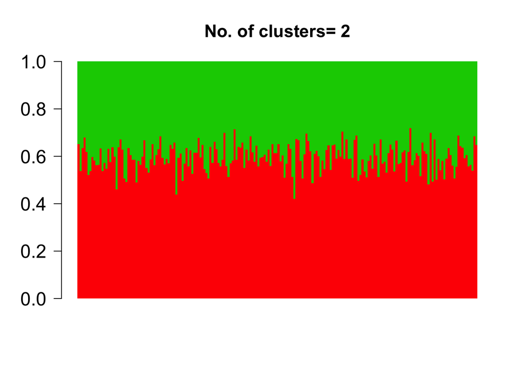

```r
K=2
barplot(t(Topic_clus$omega),col=2:(K+1),axisnames=F,space=0,border=NA,main=paste("No. of clusters=",K),las=1,ylim=c(0,1),cex.axis=1.5,cex.main=1.4)
```

Next we consider the analog of the second example of set up 1. Here the admixture proportion is taken to be all 1 for the first cluster.

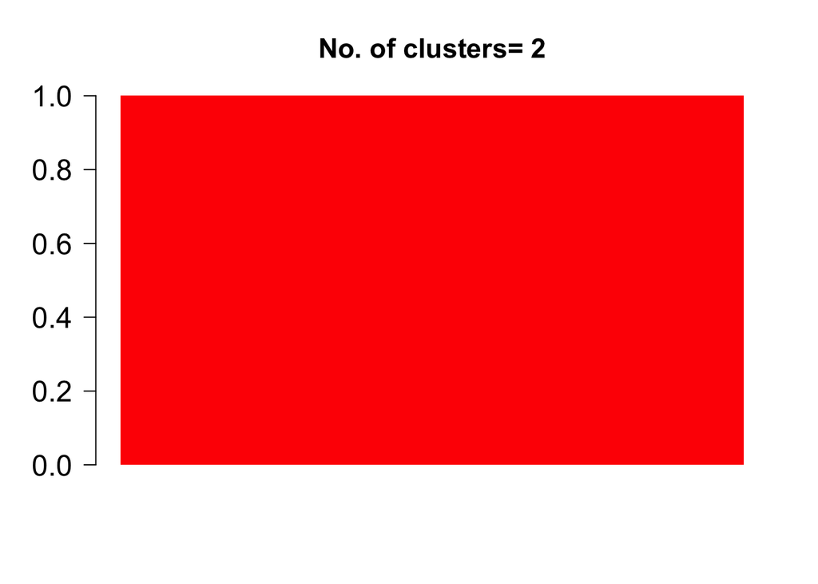

```r
library(maptpx)
n.out <- 200
omega_sim <- cbind(rep(1,n.out), 1- rep(1,n.out));
K <- dim(omega_sim)[2];
barplot(t(omega_sim),col=2:(K+1),axisnames=F,space=0,border=NA,main=paste("No. of clusters=",K),las=1,ylim=c(0,1),cex.axis=1.5,cex.main=1.4)
```

However the relative gene expression is of the form $0.6P_1 + 0.4P_2$ and $0.4P_1 + 0.6P_2$.

```r
freq2 <- matrix(0,2,length(freq1[1,]))
freq2[1,] <- 0.6*freq1[1,]+0.4*freq1[2,];
freq2[2,] <- 0.6*freq1[2,]+0.4*freq1[1,];
```

Next we generate the counts data and apply the Admixture model and plot the Structure plot.

```r
counts <- t(do.call(cbind,lapply(1:dim(omega_sim)[1], function(x) rmultinom(1,1000,prob=omega_sim[x,]%*%freq2))));

Topic_clus <- topics(counts, K=2,tol=0.001);
```

```
##
## Estimating on a 200 document collection.
## Fitting the 2 topic model.
## log posterior increase: 28.438, 1.39, 0.493, 0.437, 0.392, 0.356, 0.326, 0.302, 0.28, 0.262, 0.247, 0.233, 0.222, 0.211, 0.202, 0.194, 0.187, 0.18, 0.175, 0.169, 0.165, 0.161, 0.157, 0.154, 0.151, 0.148, 0.146, 0.143, 0.141, 0.139, 0.138, 0.136, 0.135, 0.133, 0.132, 0.131, 0.129, 0.128, 0.127, 0.…
```

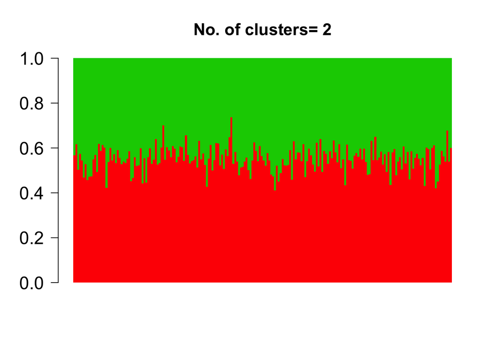

```r
K=2
barplot(t(Topic_clus$omega),col=2:(K+1),axisnames=F,space=0,border=NA,main=paste("No. of clusters=",K),las=1,ylim=c(0,1),cex.axis=1.5,cex.main=1.4)
```

The gene annotations reveal the top genes as

```
## [1]  23  95 100   9
```